# Exam_One_A

# Terminology

1. What is the difference between a *population* and a *sample*?

Answer: A population is the entire data set for something, for example the population of Colorado and a sample is a subgroup of the population, ex: only southwest Colorado.

good

2. What is the difference between a *statistic* and a *parameter*. Give an example of a *statistic*.

Answer: A statistic is a numeric characteristic of a sample. For example, the mean height of women in Math 319 at Fort Lewis College. A parameter is a numeric characteristic of a population.

good

3. In a data set, what is the difference between an *observation* and a *variable*?

Answer: An observation is the number of occurances in data (in a data set the observations are the rows). A variable is the different characteristics recorded for the data set (in a data set the variables are the columns)

good (9/9)

# Exploratory Data Analysis

Use one of the following two chunks to load the data set `Alelager`.

If you have the `resampledata` package installed use:

```r
library(resampledata)
BeerData<-Alelager
head(BeerData)
```

```
##   ID Type Alcohol Calories
## 1  1  Ale    5.50      160
## 2  2  Ale    5.40      156
## 3  3  Ale    4.85      146
## 4  4  Ale    4.50      150
## 5  5  Ale    5.20      160
## 6  6  Ale    5.30      174
```

```r
dim(BeerData)
```

```
## [1] 31  4
```

**or**, you can use:

```r
#BeerData<-read.csv("https://sites.google.com/site/chiharahesterberg/data2/Alelager.csv")
#head(BeerData)
```

1. Create side-by-side box plots of the alcohol content, grouped by beer type. Comment on the information the box plots convey.

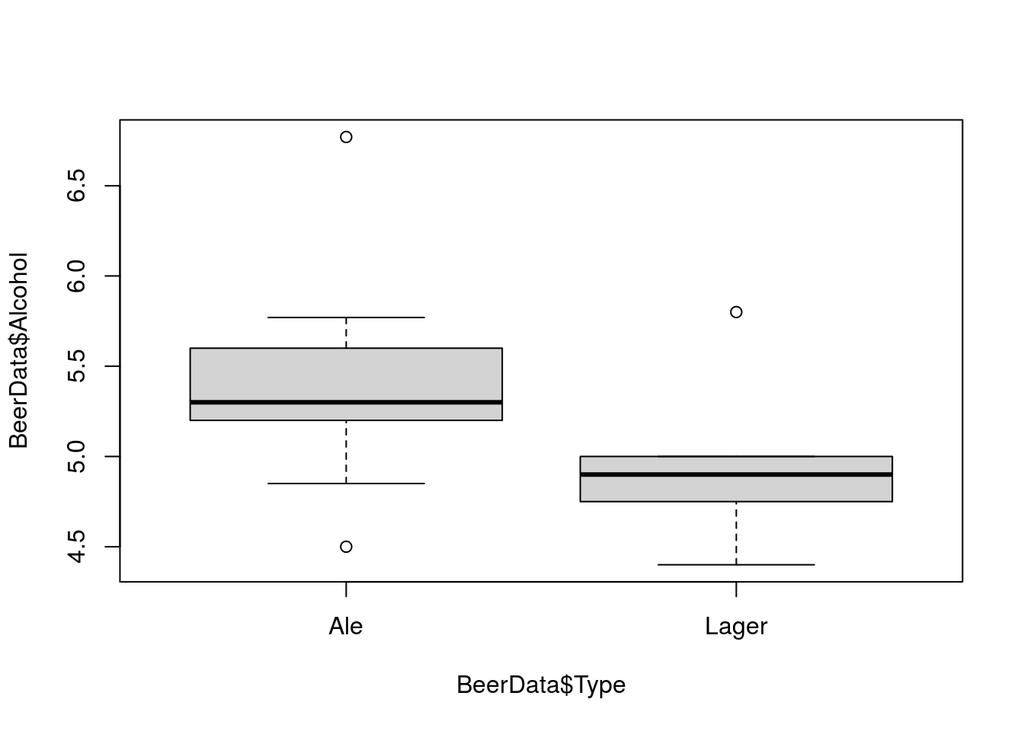

```r
boxplot(BeerData$Alcohol~BeerData$Type)
```

Commentary: They are not very comparable. The Beer types have different spread and different median values.

good

2. Create a histogram of the calorie content of all beers in the data set. Describe the distribution.

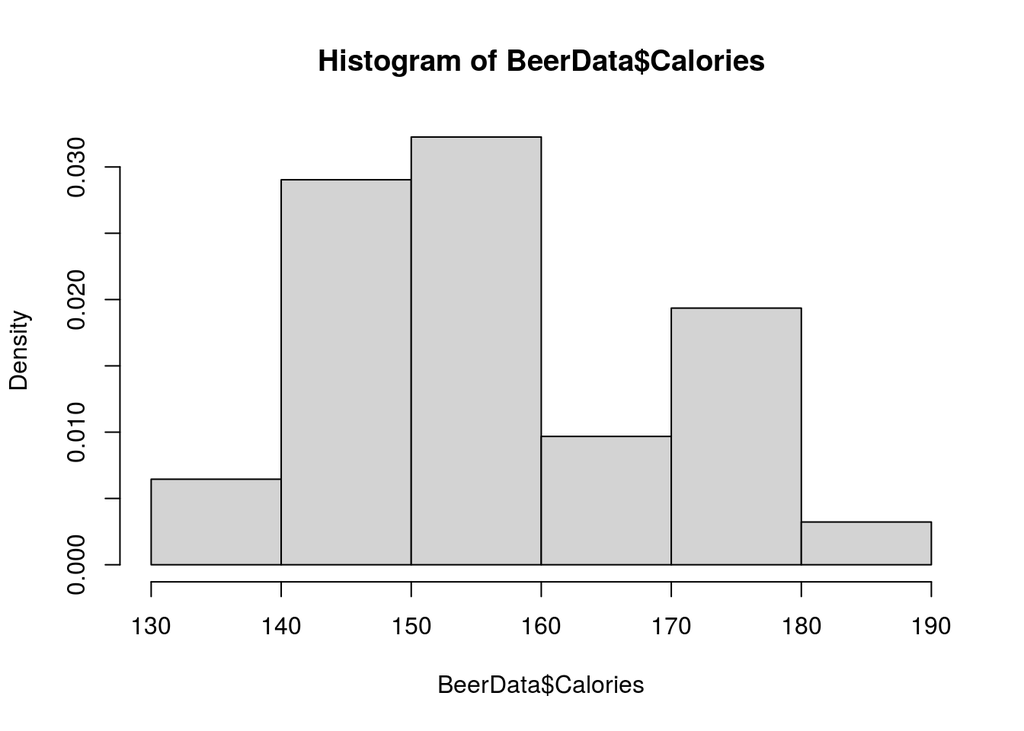

```r
hist(BeerData$Calories, freq = F)
```

Description of distribution: The distribution is not a normal distribution, it doesn’t follow the bell curve. It looks to be skewed right.

good (6/6) (15/15)

3. Sampling Distribution
- Simulate the sampling distribution of the mean of the number of calories, for samples of size 3.

```r
N=10^4
Xbar <- numeric(N)
for (i in 1:N)
  {mysample <- sample(BeerData$Calories, size=3,replace=F)
  Xbar[i] <- mean(mysample)}
```

- Create a histogram and describe the simulated sampling distribution.

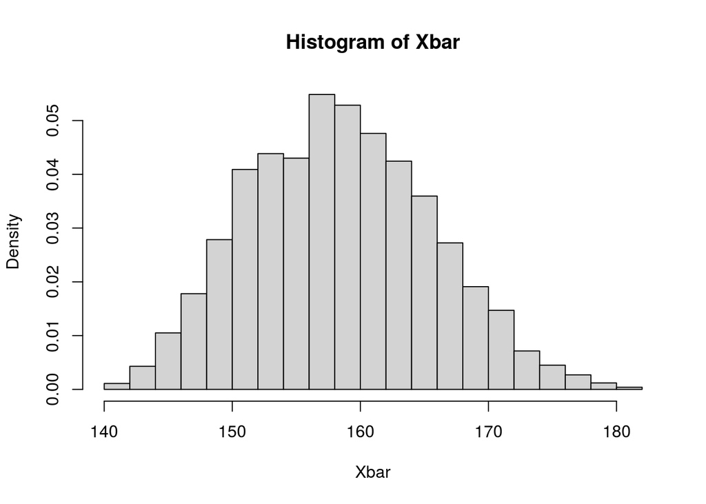

```r
hist(Xbar, freq = F)
```

Description of sampling distribution: This looks to be a normal distribution slightly skewed right.

- Use the simulation to find the probability that the average calorie content of 3 beers is less than 150 calories.

```r
N=10^4
Xbar <- numeric(N)
for (i in 1:N)
  {mysample <- sample(BeerData$Calories<150, size=3,replace=F)
  Xbar[i] <- mean(mysample)}
```

- Use the simulation to find the probability that the average calorie content of 3 beers is more than 160 calories.

```r
N=10^4
Xbar <- numeric(N)
for (i in 1:N)
  {mysample <- sample(BeerData$Calories>160, size=3,replace=F)
  Xbar[i] <- mean(mysample)}
```

eg: the second probability is mean(Xbar>160) (5/7) (20/22)

4. The following code generates two ecdfs, one for calories of ales, one for calories of lagers.

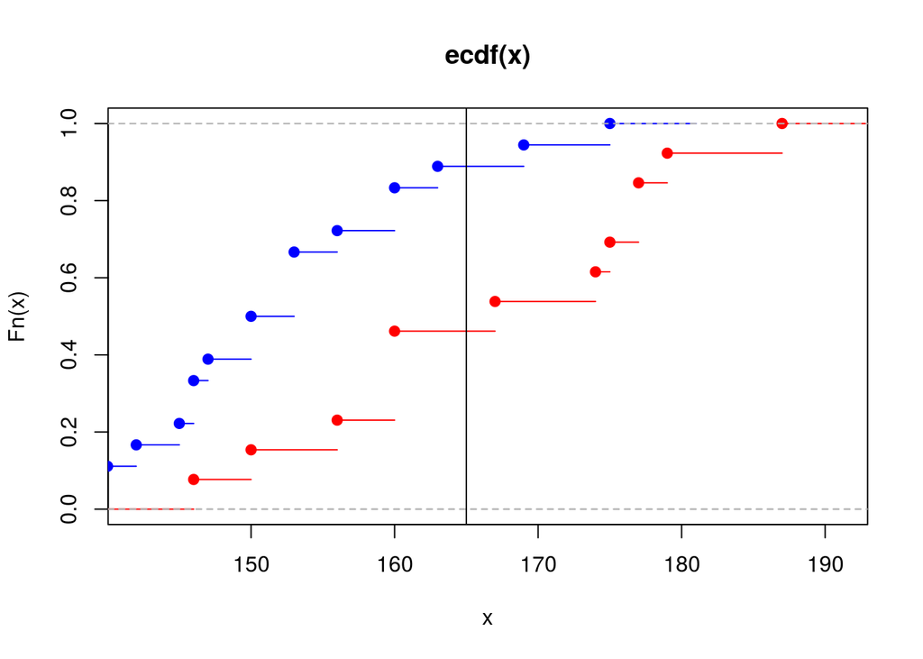

```r
Ales <- subset(BeerData, select=Calories, subset=Type=="Ale", drop=T)
Lagers <- subset(BeerData, select=Calories, subset=Type=="Lager", drop=T)
#plot.new()
plot.ecdf(Ales, col="red")
plot.ecdf(Lagers, col="blue", add=TRUE)
abline(v=165)
```

What percentage of ales in the data set have less than 165 calories? Approximately 45%

What percentage of lagers in the data set have less than 165 calories? Approximately 85%

good (3/3) (23/25)

# Permutation test

Conduct a permutation test to determine whether there is a difference in the mean calorie content between ales and lagers. Your test should start with a statement of the formal hypotheses and finish with a conclusion.

Put each step in its own chunk and **clearly explain what each chunk is doing and what information the output provides.**

Step 1: State hypothesis: Null hypothesis, mean(ales)-mean(lagers)=0 Alternative hypothesis, mean(ales)-mean(lagers) does not equal 0

Step 2: Find observed mean

```r
observed <- mean(Ales)-mean(Lagers)
observed
```

```
## [1] 14.21368
```

Step 3: Resampling from all of the Calories

```r
N <- 10^4-1
result <- numeric(N)
for (i in 1:N)
{index <- sample(length(BeerData$Calories),size=length(Ales), replace=F)
result[i] <- mean(BeerData$Calories[index])-mean(BeerData$Calories[-index])}
```

Look at results in a histogram.

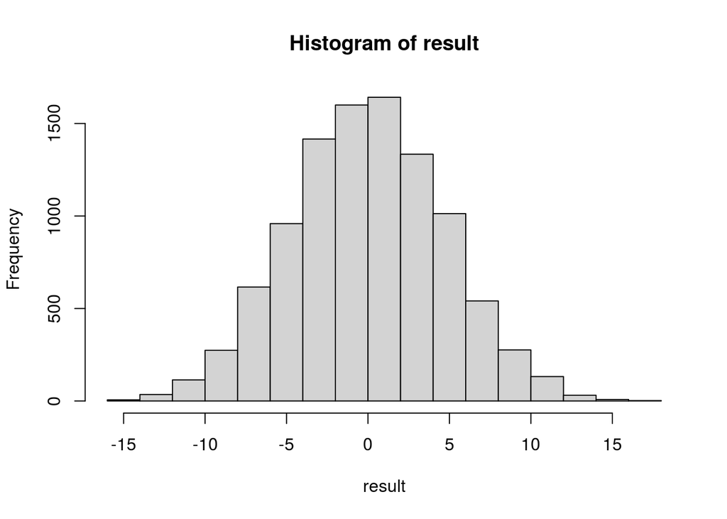

```r
hist(result)
```

Step 4: Compare the resampling mean value with the observed mean value.

```r
2*min((sum(result >= observed)+1)/(N+1),
(sum(result <= observed)+1)/(N+1))
```

```
## [1] 0.0022
```

Conclusion: The probability is a sufficiently small number (<0.05) therefore the null hypothesis can be rejected. There is a significant statistical difference between ales and lagers.

(I put in several r-chunks. You might use more, you might use fewer.)

good (13/13) (36/38)

# Critical reading

Below, I conduct a permutation test to test whether there was, on average, a difference in the annual snow fall in Colorado in the years 2019 and 2020. Identify the mistake and fix it.

First, we load and briefly inspect the data:

```r
SnowData <- read.csv("https://www.dropbox.com/s/h8lkjdqoqui3bzw/TestDownload2.csv?dl=1")
head(SnowData)
```

```
##                           StationName Snow2020 Snow2019
## 1               BAYFIELD 6.2 N, CO US     55.3    182.1
## 2 BLACK CANYON OF THE GUNNISON, CO US    103.9    165.0
## 3           BLACK FOREST 3.8 W, CO US    110.4    184.6
## 4           BLACK FOREST 6 WNW, CO US     73.9    125.3
## 5                BOULDER 1.6 S, CO US    124.4    124.8
## 6                BOULDER 2.9 S, CO US    113.9    116.0
```

The data shows annual snow fall recorded at 51 NOAA weather station in Colorado in 2019, and 2020.

The formal statements of the hypotheses are:

$$H_0: \mu_{d_{2020}-d_{2019}}=0$$

$$H_A: \mu_{d_{2020}-d_{2019}}\neq 0$$

where $d_{2020}-d_{2019}$ represents the difference in snow fall by station.

*It is the mean of the differences, not difference of the means*

We’ll compute the difference in snowfall at each station and compute the observed mean of differences:

```r
DiffAtStations<-SnowData$Snow2020-SnowData$Snow2019
Observed<-mean(DiffAtStations)
Observed
```

```
## [1] -25.45098
```

Next, we’ll pool the data in order to find a permutation distribution:

```r
poolsize <- length(SnowData$Snow2020)
```

Here is the loop that generates a permutation distribution:

```r
N=10^4-1
result2<-numeric(N)
for (i in 1:N)
{Sign <- sample(c(-1,1), poolsize, replace=T)
Diff <- Sign*DiffAtStations
result2[i]<- mean(Diff)}
```

Finally, we compute the $p$-value for our observed statistic:

```r
min((sum(result2 >= Observed)+1)/(N+1),
(sum(result2 <= Observed)+1)/(N+1))
```

```
## [1] 1e-04
```

Since the $p$-value is small we reject the null hypothesis and conclude that the mean difference in snow depth between 2019 and 2020 was different.

good (5/5) (41/43)